# STAT-S 610: Final Project

Luis Navarro

December 2022

# Background

- Suppose we want to analyze the effect of a policy intervention/treatment $Treat$ on the population.
- Ideally, we can estimate the following linear regression model and retrieve the Average Treatment Effect (ATE) by looking at the coefficient estimate of $\theta$.

$$\begin{equation}
y_i = \beta_0 + \theta Treat_i + \gamma x_i + e_i
\end{equation}$$

- Problem with observational studies is that the treatment is not randomly assigned, so without good control variables $x$ the coefficient estimate of $\theta$ will be biased.

# Solution

- *Difference-in-Difference (DID) model* Treatment vs control group comparison, before and after the intervention. The coefficient of interest is $\beta$ as it retrieves the ATE.

$$\begin{equation}
y_{it} = \beta_0 + \theta_1 Treat_i + \theta_2 Post_t + \beta (Treat_i
\times Post_t) + \gamma x_{it} + e_{it}
\end{equation}$$

- For this estimates to be accurate, the selection of the control group is crucial.
- Treatment and control groups should be as good as identical, such that the only observed difference after the intervention could be attributed to the treatment.

# Improving the control group

- In practice we can overcome this by running Eq 2 using weighted least squares with Inverse Probability Weights (IPW).
- These weights are computed estimating a model for the probability of receiving the treatment (i.e. propensity score) using a Logit model.

$$\begin{equation}
Treat_{i} = g(X_i \beta + e_i)
\end{equation}$$

- *My project* implement a forward stepwise regression algorithm to choose the Propensity Score Model (PSM) with highest prediction accuracy. Then use such weights to estimate the DID model and test to which extent it reduced the bias on the ATE estimate.

# Top Down Design

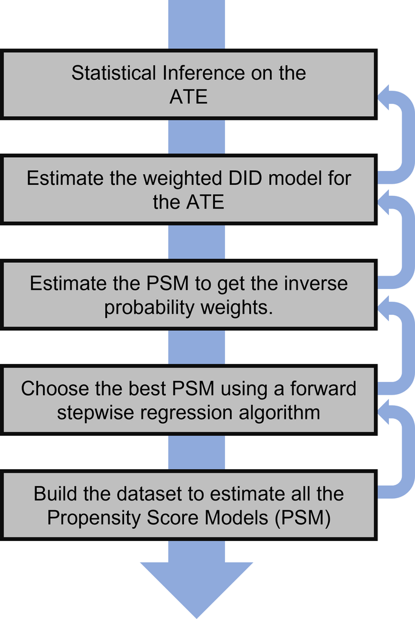

```r
knitr::include_graphics("C:/Users/luise/OneDrive - Indiana University/Statistical Computing/Final_Project/topdown.png")
```

- Five main functions and one auxiliary function to do statistical inference.

# Notation

- Outcome: independent variable in the regression.
- Treatment variable: dummy variable denoting treatment status (=1 if treated).
- Post variable: dummy variable equal to one after the intervention.
- Time variable $t$: discrete variable measuring time (e.g. year)
- Unit variable $i$: unit identifier (in my case US counties)
- Data - DID model: panel data set having observations for outcome $y_{it}$ across units and periods.
- Data - PSM model: cross-sectional observations of characteristics $X_i$ that determine treatment assignment.

# Function 1: Randomization Inference for the ATE

```r
did_randomization <- function(outcome, treat_var, treat_period, time_var, unit_var,
    weights, data, samples) {
    ### Estimate the Difference-in-Difference Model
    baseline_model <- did_model(outcome, treat_var, treat_period, time_var, unit_var,
        weights, data)
    ### Randomization Inference to Compute SE, Conf Int and p-values
    empirical_distribution <- matrix(nrow = samples, ncol = 1)
    i = 1
    while (i <= samples) {
        ### Create a Placebo treatment that is randomly assigned
        data_sample <- random_treatment(unit_var, data)
        ### Estimate the model with random treatment variable
        model_estimate <- did_model(outcome = outcome, treat_var = "random_treat",
            treat_period = treat_period, time_var = time_var, unit_var = unit_var,
            weights = weights, data = data_sample)
        empirical_distribution[i, 1] <- coef(model_estimate)
        i = i + 1
    }
    ### Average Treatment Effect
    ate <- coef(baseline_model) %>%
        as.double()
    ### Standard Error: standard deviation from the empirical distribution
    std_error <- sd(empirical_distribution) %>%
        as.double()
    ### P-value: % of times the placebo treatment effect is larger than the
    ### estimated treatment effect
    pval <- sum(empirical_distribution >= ate)/samples %>%
        as.double()
    model_results <- data.frame(coefficient = ate, std_error = std_error, pval = pval)
    ### Do a graph showing the hypothesis graphically.Density Plot of the
    ### Empirical Distribution
    empirical_distribution <- empirical_distribution %>%
        as.data.frame() %>%
        mutate(ATE = ate)
    density_plot <- ggplot(empirical_distribution, aes(x = V1)) + geom_density(alpha = 0.25) +
        geom_vline(aes(xintercept = mean(ATE)), color = "red", linetype = "dashed") +
        theme_bw() + geom_density(color = "darkblue") + labs(title = "Placebo Distribution of the Average Treatment Effect",
        y = "Density", x = "Parameter Estimate")
    ### Output as a list, with a DF with the results and the graph
    ouput <- list(model_results, density_plot)
    return(ouput)
}
```

Auxiliary Function: Create a placebo treatment that is randomly assigned to the population.

```r
random_treatment <- function(unit_var, data) {
    data_treat <- data
    names(data_treat)[which(colnames(data_treat) == unit_var)] <- "unit_var"
    ### Get A list of unique treatment units
    treat_units <- unique(data_treat$unit_var)
    ### Create a fake random treatment
    random_treat <- round(runif(length(treat_units)))
    ### Map of Randomized Treatment
    random_assignment <- data.frame(unit_var = treat_units, random_treat = random_treat)
    ### Merge with the data set
    data_treat <- merge(data_treat, random_assignment, by = "unit_var")
    return(data_treat)
}
```

# Function 2: Estimate the ATE through a DID model.

```r
### Difference in difference regression model
did_model <- function(outcome, treat_var, treat_period, time_var, unit_var, weights,
    data) {
    ### Rename Variables For Simplicity and consistency.
    data_model <- data  ### Define object inside the function env to avoid writing in the input.
    names(data_model)[which(colnames(data_model) == outcome)] <- "outcome"
    names(data_model)[which(colnames(data_model) == treat_var)] <- "treat_var"
    names(data_model)[which(colnames(data_model) == time_var)] <- "time_var"
    names(data_model)[which(colnames(data_model) == unit_var)] <- "unit_var"
    ### If missing weights, assign equal weights such that WLS = OLS
    if (is.null(weights)) {
        uniform_weights <- rep(1, length(data_model$unit_var))
        data_model <- mutate(data_model, weights = uniform_weights)
    } else {
        names(data_model)[which(colnames(data_model) == weights)] <- "weights"
    }

    ### Create Post Variable for the DID Model
    data_model <- mutate(data_model, time_post = case_when(data_model$time_var <=
        treat_period ~ 0, data_model$time_var > treat_period ~ 1), did_var = treat_var *
        time_post)
    ### Estimate the Regression Model with IP weights
    model_did <- feols(outcome ~ did_var | unit_var + time_var, data = data_model,
        weights = ~weights)
    return(model_did)
}
```

# Function 3. Estimate the Propensity Score Model

- Note: for this function the outcome is not $y_{it}$. It is $Treat_i$ because we are estimating the propensity score model.

```r
psm_weights <- function(outcome,predictors,unit_var,data) {
### Get the model with highest accuracy
model <- model_selection(outcome, predictors, unit_var, data)
### Optimal set of predictor variables
predictor_star <- model[[1]]
### Build the data set to run the PS models.
reg_data <- data_build(outcome, predictors, unit_var, data)
### Get the data set with the chosen variables
data_build_psm <- subset(reg_data, select = c("outcome", unit_var, predictor_star))
### PSM Formula
reg_form <- as.formula(paste("outcome", paste(predictor_star, collapse = " + "),
                             sep = " ~ "))
### Estimate the Propensity Score Model
psm_model <- glm(reg_form, data = data_build_psm,
                 family = binomial(link = "logit"))
# Generate propensity scores and IPWs
psm_weights <- data_build_psm %>% mutate(propensity = psm_model$fitted.values) %>%
                        mutate(ipw = ifelse(outcome == 1, 1/propensity, 1/(1-propensity)))
### Compute the Prediction Error of the Model
data_results <- data_build_psm %>% mutate(predicted = psm_model$fitted.values) %>%
  mutate(outcome = as.double(outcome)) %>%
  mutate(sq_error = (outcome - predicted)^2)

### Accuracy Metric: Root Mean Squared Prediction Error
rmspe <- data_results$sq_error %>% mean() %>% sqrt()
### Return Data Frame with Unit Var and IPW weights
psm_results <- list(model, psm_weights, rmspe)
return(psm_results)
```

# Function 4. Forward Stepwise Selection Model Selection

```r
model_selection <- function(outcome, predictors, unit_var, data) {
    ### Build data set with organized variables to test the model.
    reg_data <- data_build(outcome, predictors, unit_var, data)
    ### Initial Set of Predictors: all variables but the outcome and the id
    ### variable.
    predictors_i <- colnames(reg_data)[-which(colnames(reg_data) == c("outcome") |
        colnames(reg_data) == c(unit_var))]
    pred_no <- length(predictors_i)  ### Number of predictors to test
    predictor_star <- NULL  ### Empty vector to store the chosen predictors
    rmspe_master <- matrix(data = NA, nrow = pred_no, ncol = 2)  ## Empty matrix to store the accuracy of each model
    rmspe_old = 1000  ### Arbitrarily chosen large prediction error.
    j = 1
    ### The Loop will run until we ran out of possible predictor variables.
    ### This is an forward stepwise selection algorithm. It begins with a
    ### simple univariate regression and iteratively augments the model by
    ### choosing the variable that improves more the RMSPE. If there is no
    ### improvement, then break the loop and return the model.
    while (pred_no > 0) {
        rmspe <- matrix(data = NA, nrow = pred_no, ncol = 3)
        for (i in 1:pred_no) {
            ### Model Definition
            data_subset <- subset(reg_data, select = c("outcome", predictor_star,
                predictors_i[i]))
            ### Estimate the logit model with all the variables in the data
            ### set.
            psm_model <- glm(outcome ~ ., data = data_subset, family = binomial(link = "logit"))
            ### Store Predicted Values and compute the Squared Prediction Error
            data_results <- data_subset %>%
                mutate(predicted = psm_model$fitted.values) %>%
                mutate(outcome = as.double(outcome)) %>%
                mutate(sq_error = (outcome - predicted)^2)

            ### Accuracy Metric: Root Mean Squared Prediction Error
            rmspe_new <- data_results$sq_error %>%
                mean() %>%
                sqrt()
            rmspe[i, 1] <- i  ### Store the Results of the RMSPE for each estimated model
            rmspe[i, 2] <- rmspe_new  ### Store the Accuracy of the model.
            rmspe[i, 3] <- rmspe_old - rmspe_new  ### Compute the Accuracy Improvement relative to the previous lap of the loop
        }

        ### Store Outer Loop Results
        rmspe_master[j, 1] <- j
        rmspe_master[j, 2] <- min(rmspe[, 2])
        ### Choose the Model with highest accuracy improvement
        model_index <- rmspe[which(rmspe[, 3] == max(rmspe[, 3])), 1]
        ### Choose the predictor with highest accuracy
        predictor_star <- c(predictor_star, predictors_i[model_index])
        ### Update the Number of Remaining Predictors
        predictors_i <- predictors_i[-model_index]
        pred_no <- length(predictors_i)
        ### Break if adding a variable did not improved prediction accuracy
        delta_rmspe <- rmspe_old - min(rmspe[, 2])
        if (delta_rmspe <= 0) {
            break
        }
        rmspe_old <- min(rmspe[, 2])  ### Define rmspe old for the new loop
        j = j + 1  ### Add one to the counter
    }
    results <- list(predictor_star, rmspe_master)
    return(results)
}
```

# Function 5: Build dataset to estimate PSM models

```r
data_build <- function(outcome, predictors, unit_var, data) {
    full_data <- data %>%
        na.omit()  ### Cleaning
    names(full_data)[which(colnames(full_data) == outcome)] <- "outcome"  ### Rename outcome
    full_data$outcome <- as.factor(full_data$outcome)
    unit_var <- subset(full_data, select = unit_var)
    ### Outcome has the name of the outcome variable
    y <- subset(full_data, select = outcome)
    ### Predictors is a vector with the names of all the variables that will be
    ### used as predictors
    x <- subset(full_data, select = predictors)
    #### Squared Predictors
    x2 <- x^2
    colnames(x2) <- paste0(colnames(x), ".sq")
    ### Predictors in Inverse Hyperbolic Sin Function
    xasinh <- asinh(x)
    colnames(xasinh) <- paste0(colnames(x), "asinh")
    ### Interaction Terms and Intercept
    interactions <- model.matrix(~.^2, data = x)
    inter_var <- interactions[, -which(colnames(interactions) == "(Intercept)")] %>%
        as.data.frame()
    ### Weird thing happening with the variable names when there is only one
    ### predictor
    if (length(predictors) == 1) {
        names(inter_var) <- predictors
    }
    regdata <- data.frame(unit_var, y, inter_var, x2, xasinh)  ### Return Dataframe with ordered variables
    return(regdata)
}
```

# Implementation

# Parameters of the Simulation

```r
treatment_year = 2015  ### 5 periods before and after for comparison
ate_beta = 7  ### ATE = 7
cutoff_treatment_assignment <- rnorm(1, mean = 0.4, sd = 0.15)
sample_no <- 1000  ### Sample size of the placebo distribution for inference
```

- Non-random treatment assignment.

```r
### Non Random Treatment Assignment -- Complex Non-Linear Data Generating Process function of college, female, unemployment_rate, population, age513, age4564, taxes_pc, currexp
treat_formula = unemployment_rate*female + sqrt(age4564) + sqrt(taxes_pc/exp_pc) + currexp^2 +
                log(1 + college) + log(popestimate) + rnorm(nfips, mean = 0, sd = 1),
treat_aux = percent_rank(treat_formula),
### If above the cutoff, the county is treated
treat_det = case_when(treat_aux <= cutoff_treatment_assignment ~ 0,
                      treat_aux > cutoff_treatment_assignment ~ 1),)
```

- To estimate the model, I create a fake outcome with the ATE defined above. For reference, I use the log of the property tax revenue collected by counties. $did = treat \times post$. So I know the true value of $\beta = 7$.

```r
fake_outcome = logproptax + ate_beta*(did) + treat_det + post + fips_fe + year_fe + epsilon)
```

- Composition of the treatment and control group in the simulation

```r
data_psm$treat_det %>%
    table()
```

```
## .
##   0   1
## 358 812
```

# Results from the Stepwise Regression Algorithm

- I will iteratively augment the PS model by increasing the set of variables from which is choosing.

```r
psm_dgp <- c("college", "popestimate", "female", "taxes_pc", "exp_pc", "unemployment_rate",
    "age4564", "currexp")
simulation_results <- list()
### Do the Simulation
for (k in 1:length(psm_dgp)) {
    ipw <- psm_weights(outcome = "treat_det", predictors = psm_dgp[1:k], unit_var = "fips",
        data = data_psm)
    ### IPW Weights
    ipw_weights <- subset(ipw[[2]], select = c("fips", "propensity", "ipw"))
    ### Merge IPW in the DID data set to estimate the model with and without
    ### weights
    data_did_model <- merge(data_did, ipw_weights, by = "fips")
    ### Estimate the Matched Difference-in-Difference Model. Statistical
    ### Inference is done using the placebo distribution of the treatment
    ### variable under the specified model.
    did_estimation <- did_randomization(outcome = "fake_outcome", treat_var = "treat_det",
        treat_period = 2015, time_var = "year", unit_var = "fips", weights = "ipw",
        data = data_did_model, samples = sample_no)
    simulation_results[[k]] <- list(ipw, did_estimation)
}
```

- The following graphs show how the RMSPE decreases as the algorithm chooses the predictors optimally.
- As the number of predictors increase, so the possible combinations and interactions in which they could appear.

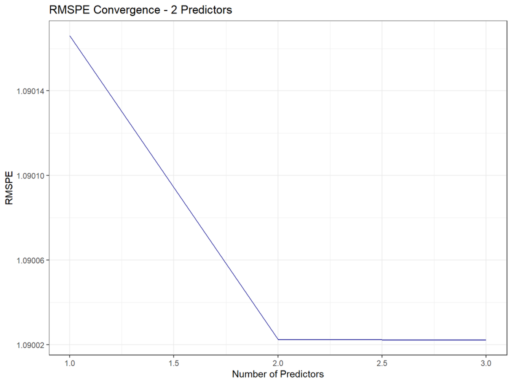

```r
print(convergence_plot2)
```

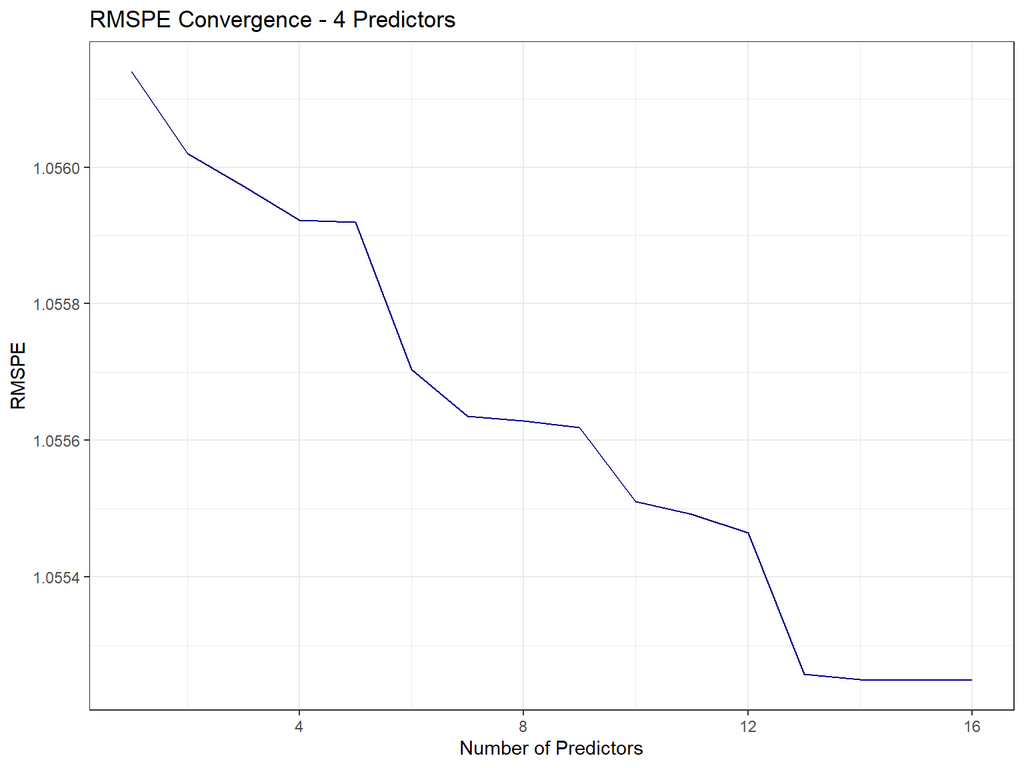

```r
print(convergence_plot4)
```

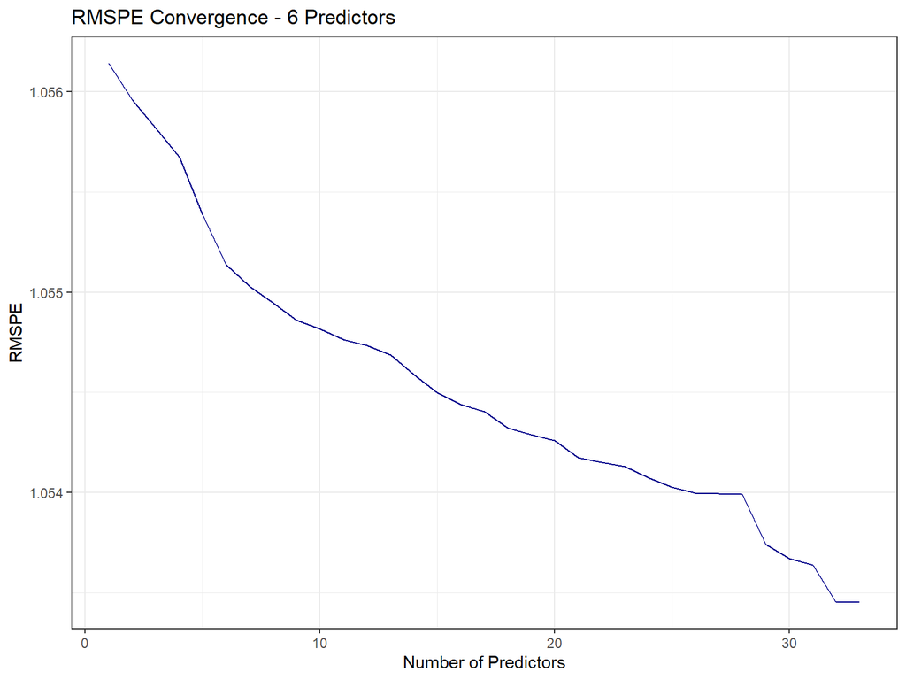

```r
print(convergence_plot6)
```

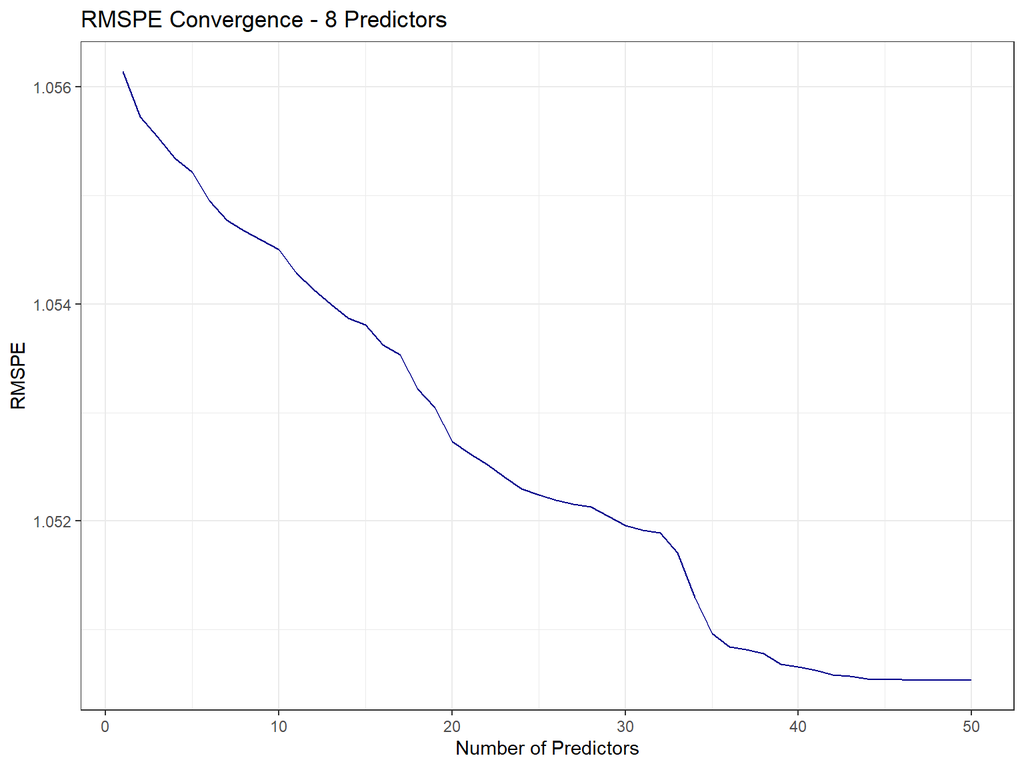

```r
print(convergence_plot8)
```

# Results from the Simulation

- Estimate the DID Unweighted model.

```r
### Estimate the Un-weighted Difference in Difference Model
unweighted_model <- did_model(outcome = "fake_outcome", treat_var = "treat_det",
    treat_period = 2015, time_var = "year", unit_var = "fips", weights = NULL, data = data_did)
unweighted_model %>%
    summary()
```

```
## OLS estimation, Dep. Var.: outcome
## Observations: 12,870
## Weights: weights
## Fixed-effects: unit_var: 1,170,  time_var: 11
## Standard-errors: Clustered (unit_var)
##         Estimate Std. Error t value  Pr(>|t|)
## did_var  6.95616   0.051719 134.498 < 2.2e-16 ***
## ---
## Signif. codes:  0 '***' 0.001 '**' 0.01 '*' 0.05 '.' 0.1 ' ' 1
## RMSE: 1.03857     Adj. R2: 0.947747
##                 Within R2: 0.702552
```

```r
### Results from the Simulation
t(ate) %>%
    print()
```

```
##          [,1]      [,2]     [,3]
## [1,] 6.957534 0.2516952 1.090022
## [2,] 6.972434 0.5551869 1.055988
## [3,] 6.972412 0.5420286 1.055974
## [4,] 6.961328 0.6619966 1.055250
## [5,] 6.964768 0.6782417 1.054062
## [6,] 6.977672 0.6082662 1.053454
## [7,] 6.993309 0.8199914 1.051545
## [8,] 7.014016 0.7801361 1.050539
```

- Choose the best model according to the RMSPE criterion. As we can see, it alleviates the bias.

```r
### Which one is the best model?
final_comp <- matrix(data = NA, ncol = 2, nrow = 2, dimnames = list(c("ATE", "SE"),
    c("Unweighted", "IPW")))
final_comp[1, 1] <- unweighted_model$coefficients[[1]]
final_comp[2, 1] <- unweighted_model$se[[1]]
final_comp[1, 2] <- ate[1, ate[3, ] == min(ate[3, ])]
final_comp[2, 2] <- ate[2, ate[3, ] == min(ate[3, ])]
final_comp %>%
    print()
```

[output not shown]

- Randomization Inference results:

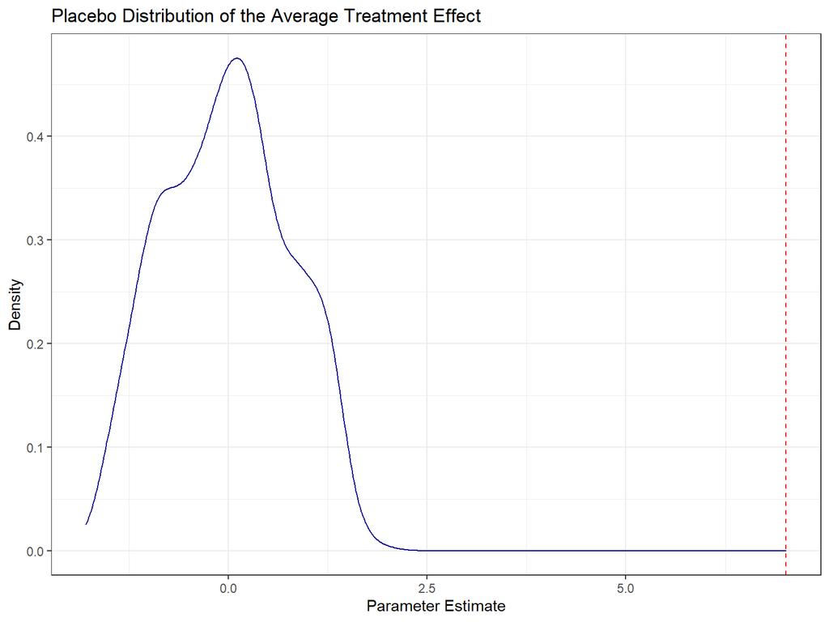

```r
stat_inference_graph <- simulation_results[[8]][[2]][[2]]
print(stat_inference_graph)
```

# Challenges and Next Steps

- The algorithm is unstable. For some parameters of the simulation, it does not improve prediction accuracy.
- Depends on the complexity of the treatment assignment rule/DGP and the threshold. Also, on the size of the ATE. For smaller values of the $ATE$ it gets harder to get statistical significance.
- For this version, I am restraining to explore straightforward ways in which variables could interact.
- Double check the randomization inference function. While I use a uniform random variable for random assignment, sometimes I observe multimodal distribution.
- You can check older implementations and current progress here: https://github.com/LuisNavarro07/stat610_finalproject